# FigureYa13GSEA_JavaV2_update

**Author(s)**: Guangchuang Yu; Ying Ge, Yijing Chen  
**Date**: `r Sys.Date()`

# Academic Citation

If you use this code in your work or research, we kindly request that you cite our publication:

Xiaofan Lu, et al. (2025). FigureYa: A Standardized Visualization Framework for Enhancing Biomedical Data Interpretation and Research Efficiency. iMetaMed. https://doi.org/10.1002/imm3.70005

## 需求描述

## Requirement description

已经用[Java版GSEA](http://software.broadinstitute.org/gsea/index.jsp)做出了GSEA分析结果，想自己画图。

图一：点图 + 条码

I have already made GSEA analysis results with [GSEA for Java](http://software.broadinstitute.org/gsea/index.jsp) and would like to draw my own plots.

Figure 1: Dot Map + Barcode

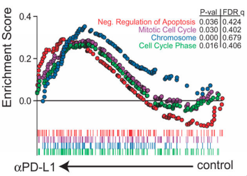

出自https://science.sciencemag.org/content/354/6316/1160

fromhttps://science.sciencemag.org/content/354/6316/1160

图二：线图 + 条码

Figure 2: Line Chart + Barcode

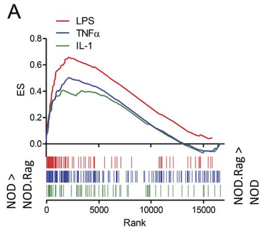

出自http://jem.rupress.org/content/214/8/2369.long

fromhttp://jem.rupress.org/content/214/8/2369.long

图三：条码 + 热图

Figure 3: Barcode + Heat Map

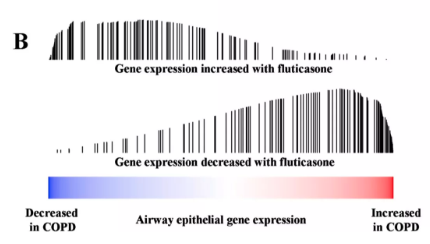

出自https://thorax.bmj.com/content/69/1/14

fromhttps://thorax.bmj.com/content/69/1/14

## 应用场景

## Application scenario

以Java版GSEA的输出结果作为输入，DIY结果图，把多个通路画到一张图里。

如果你用clusterProfiler做的GSEA分析，想要DIY结果图，把多个通路画到一张图，或者把同一通路的多组对比画在一张图上，请用FigureYa60GSEA_clusterprofiler。

Using the output of the Java version of GSEA as input, do-it-yourself result map, drawing multiple pathways into a single map.

If you do GSEA analysis with clusterProfiler and want to DIY the result plots, plot multiple pathways to a single plot, or plot multiple comparisons of the same pathway to a single plot, use FigureYa60GSEA_clusterprofiler.

## 环境设置

## Environment setting

```r
source("install_dependencies.R")
```

```
## Starting R package installation...
## ===========================================
##
## Installing CRAN packages...
## Package already installed: RColorBrewer
## Installing CRAN package: blueviolet
```

```
## Installing CRAN package: chocolate4
```

```
## Package already installed: cowplot
## Package already installed: ggplot2
## Package already installed: grid
## Package already installed: gridExtra
## Package already installed: plyr
##
## ===========================================
## Package installation completed!
## You can now run your R scripts in this directory.
```

```r
library(plyr)
library(ggplot2)
library(RColorBrewer)
library(gridExtra)
library(grid)
library(cowplot)
```

## 输入数据的准备

## Preparation of input data

Java版GSEA的输出文件夹中有每个通路的Excel文件，把你感兴趣的通路的Excel文件复制到当前文件夹。

读取xls文件，合并

Output folder of GSEA for Java has an Excel file for each pathway, copy the Excel file for the pathway you are interested in to the current folder.

Read xls file and merge

```r
fnames <- Sys.glob("*.xls")
fdataset <- lapply(fnames,read.delim)
names(fdataset) <- fnames
result <- ldply(fdataset, data.frame)
result$pathway <- unlist(strsplit(result$.id,split = ".xls"))
head(result)
```

```
##                        .id  NAME   PROBE GENE.SYMBOL GENE_TITLE
## 1 HALLMARK_COAGULATION.xls row_0  HMGCS2        null       null
## 2 HALLMARK_COAGULATION.xls row_1  PECAM1        null       null
## 3 HALLMARK_COAGULATION.xls row_2   MEP1A        null       null
## 4 HALLMARK_COAGULATION.xls row_3     F10        null       null
## 5 HALLMARK_COAGULATION.xls row_4     RGN        null       null
## 6 HALLMARK_COAGULATION.xls row_5 TMPRSS6        null       null
##   RANK.IN.GENE.LIST RANK.METRIC.SCORE RUNNING.ES CORE.ENRICHMENT  X
## 1               128         1.5102873 0.02707910             Yes NA
## 2               149         1.4459282 0.05835771             Yes NA
## 3               275         1.1225120 0.07692497             Yes NA
## 4               321         1.0491873 0.09802958             Yes NA
## 5               401         0.9534453 0.11521894             Yes NA
## 6               532         0.8143209 0.12663577             Yes NA
##                pathway
## 1 HALLMARK_COAGULATION
## 2 HALLMARK_COAGULATION
## 3 HALLMARK_COAGULATION
## 4 HALLMARK_COAGULATION
## 5 HALLMARK_COAGULATION
## 6 HALLMARK_COAGULATION
```

```r
# pathway的颜色，自定义足够多的颜色
# color of the pathway, customize enough colors
mycol <- c("red","navy","darkgreen","blueviolet","chocolate4")
```

## 开始画图

## Start drawing

用官方GSEA输出的Excel文件重新画图，画这种散点图最合适。如果画折线图，你会发现跟Java版GSEA输出的图像不一致。那是因为官方GSEA输出的Excel文件不是所有基因的enrichment score，它只给出了这个通路内的基因的enrichment score。

Redrawing the image with the official GSEA output Excel file is best for drawing this kind of scatterplot. If you draw a line graph, you will find that it is not consistent with the image output from the Java version of GSEA. That’s because the official GSEA output Excel file is not the enrichment score for all genes, it only gives the enrichment score for genes within this pathway.

### 图一：点图（enrichment score） + 条码（rank）

### Figure 1: Dot Plot (enrichment score) + Barcode (rank)

先画点图

First, draw a dot plot.

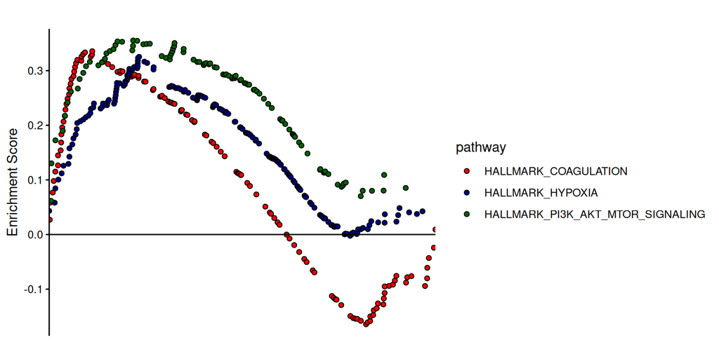

```r
ppoint <- ggplot(result, aes(x=RANK.IN.GENE.LIST,
                             y=RUNNING.ES,fill=pathway,group=pathway))+
  #用带黑圈的点，优点是在点密集的位置也能看出有多个点
  #the advantage of using dots with black circles is that you can see that there are multiple dots in locations where the dots are dense
  geom_point(shape=21) +
  scale_fill_manual(values = mycol) + #用自定义的颜色画点 draw dots with custom colors
  labs(x = "", y = "Enrichment Score", title = "") +
  scale_x_continuous(expand = c(0, 0)) + #让x和y轴都从0开始 let both the x and y axes start at 0
  scale_y_continuous(expand = c(0, 0),
                     limits =c(min(result$RUNNING.ES-0.02), max(result$RUNNING.ES+0.02))) +
  theme_classic() +
  theme(axis.line.x = element_blank(),axis.ticks.x = element_blank(),axis.text.x = element_blank()) + #去除x轴 remove x-axis
  geom_hline(yintercept = 0) #在0的位置画x轴 draw the x-axis at position 0
ppoint
```

如果pathway不多，还可以把legend画在左下角

If there are not many pathways, you can also draw the legend in the bottom left corner

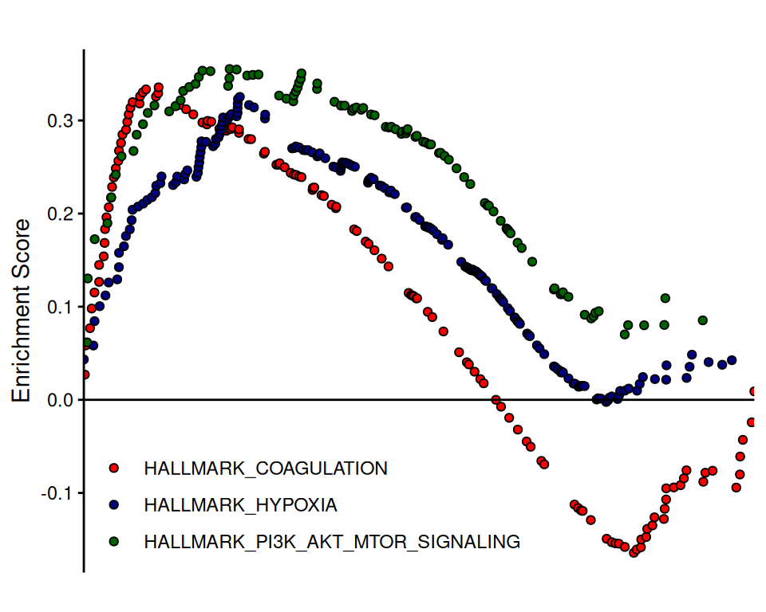

```r
ppoint2 <- ppoint + theme(legend.position=c(0,0),legend.justification = c(0,0)) +
  guides(fill=guide_legend(title = NULL)) + #隐藏由fill产生的图例的title hide the title of the legend generated by the fill
  theme(legend.background = element_blank()) +
  theme(legend.key = element_blank())
ppoint2
```

```r
#可以用ggsave保存到文件
#you can save it to a file using ggsave
#ggsave(file="ppoint2.pdf")
```

再画条码

散点图和后面的条码图本身就已经显示了gene rank，其实只有画线图的时候需要另外画gene rank。

Redraw barcode

The scatterplot and the barcode plot behind it already show the gene rank by itself, in fact, only the line plot needs to draw the gene rank separately.

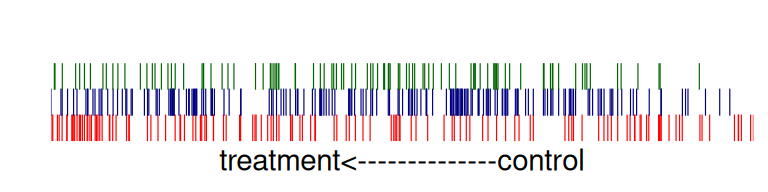

```r
prank <- ggplot(result,aes(RANK.IN.GENE.LIST,pathway,colour=pathway))+
  geom_tile()+
  theme_bw() + #去除背景色 remove background color
  scale_color_manual(values = mycol) + #用自定义的颜色画点 draw dots with custom colors
  labs(x = "treatment<--------------control", y = "", title = "") +
  scale_x_discrete(expand = c(0, 0)) + scale_y_discrete(expand = c(0, 0)) +#让x和y轴都从0开始 let both the x and y axes start at 0
  theme(panel.grid =element_blank()) + #去除网格线 remove gridlines
  theme(panel.border = element_blank()) + #去除外层边框 remove outer border
  theme(axis.line = element_line(colour = "black"))+
  theme(axis.line.y = element_blank(),axis.ticks.y = element_blank(),axis.text.y = element_blank())+ #去除y轴 remove y-axis
  guides(color=FALSE)#隐藏由color产生的图例 hide the legend generated by color
prank
```

组图

Composite image

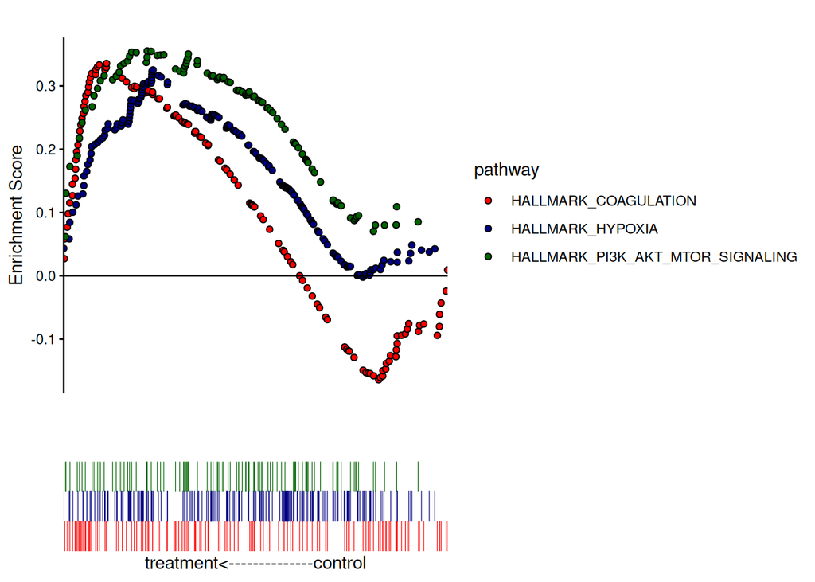

```r
#用gridExtra保持上下两个图各自的高度
#use gridExtra to keep the heights of the top and bottom graphs separate
gA=ggplot_gtable(ggplot_build(ppoint)) #或ppoint2 or ppoint2
gB=ggplot_gtable(ggplot_build(prank))
maxWidth = grid::unit.pmax(gA$widths, gB$widths)
gA$widths <- as.list(maxWidth)
gB$widths <- as.list(maxWidth)

#然后用grid组合两个图，按同一个x坐标上下对齐
#then combine the two plots with a grid, aligning them up and down by the same x-coordinate
grid.newpage()
grid.arrange(arrangeGrob(gA,gB,nrow=2,heights=c(.8,.3)))
```

```r
# 输出到文件
# output to file
pdf('prettyGSEApoint.pdf',width=8,height=4)
grid.arrange(arrangeGrob(gA,gB,nrow=2,heights=c(.8,.3)))
dev.off()
```

### 图二：线图（enrichment score） + 条码（rank）

### Figure 2: Line graph (enrichment score) + Barcode (rank)

先画线图

Draw a line graph first

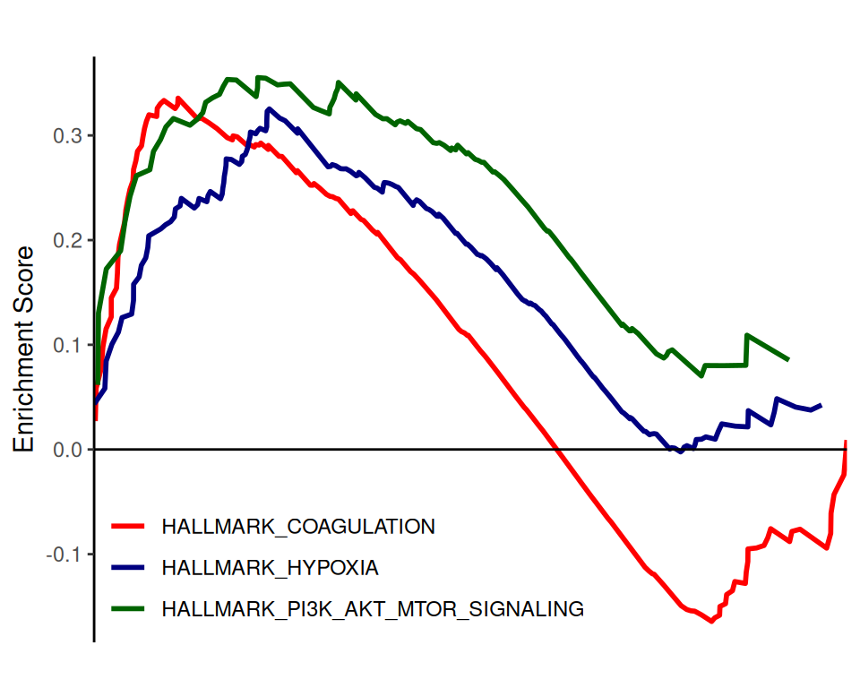

```r
pline <- ggplot(result,aes(x=RANK.IN.GENE.LIST,y=RUNNING.ES,colour=pathway,group=pathway))+
  geom_line(size=1) +
  scale_color_manual(values = mycol) + #用自定义的颜色画点 draw dots with custom colors
  labs(x = "", y = "Enrichment Score", title = "") +
  scale_x_continuous(expand = c(0, 0)) + #让x和y轴都从0开始 let both the x and y axes start at 0
  scale_y_continuous(expand = c(0, 0),
                     limits =c(min(result$RUNNING.ES-0.02), max(result$RUNNING.ES+0.02))) +
  theme_bw() + #去除背景色 remove background color
  theme(panel.grid =element_blank()) + #去除网格线 remove gridlines
  theme(panel.border = element_blank()) + #去除外层边框 remove outer border
  theme(axis.line = element_line(colour = "black")) +
  theme(axis.line.x = element_blank(),axis.ticks.x = element_blank(),axis.text.x = element_blank()) + #去除x轴 remove x-axis
  geom_hline(yintercept = 0) + #在0的位置画x轴 draw the x-axis at position 0
  theme(legend.position=c(0,0),legend.justification = c(0,0)) + #legend画在左下角 the legend is drawn in the lower left corner
  guides(colour=guide_legend(title = NULL)) + #隐藏由color产生的图例的title hide the title of the legend generated by color
  theme(legend.background = element_blank()) +
  theme(legend.key = element_blank())
pline
```

跟前面的条码图组图

Combine with the previous barcode image

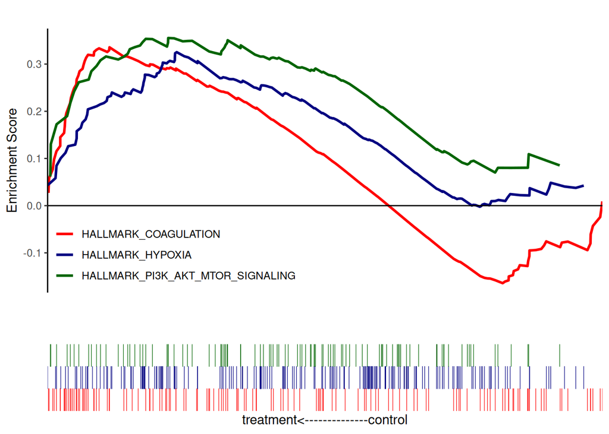

```r
#用gridExtra保持上下两个图各自的高度
#use gridExtra to keep the heights of the top and bottom graphs separate
gA=ggplot_gtable(ggplot_build(pline))#换成p1试试看 try p1 instead.
gB=ggplot_gtable(ggplot_build(prank))
maxWidth = grid::unit.pmax(gA$widths, gB$widths)
gA$widths <- as.list(maxWidth)
gB$widths <- as.list(maxWidth)

#然后用grid组合两个图，按同一个x坐标上下对齐
#then combine the two plots with a grid, aligning them up and down by the same x-coordinate
grid.newpage()
grid.arrange(arrangeGrob(gA,gB,nrow=2,heights=c(.8,.3)))
```

```r
# 输出到文件
# output to file
pdf('prettyGSEAline.pdf',width=5,height=4)
grid.arrange(arrangeGrob(gA,gB,nrow=2,heights=c(.8,.3)))
dev.off()
```

### 图三：条码（enrichment score + rank） + 热图

### Figure 3: Barcode (enrichment score + rank) + Heatmap

类似于散点图，同样要先把该通路中基因的enrichment score提取出来。

一次画一个，画到list里

Similar to a scatterplot, again the enrichment score of the genes in the pathway has to be extracted first.

Draw one at a time into the list

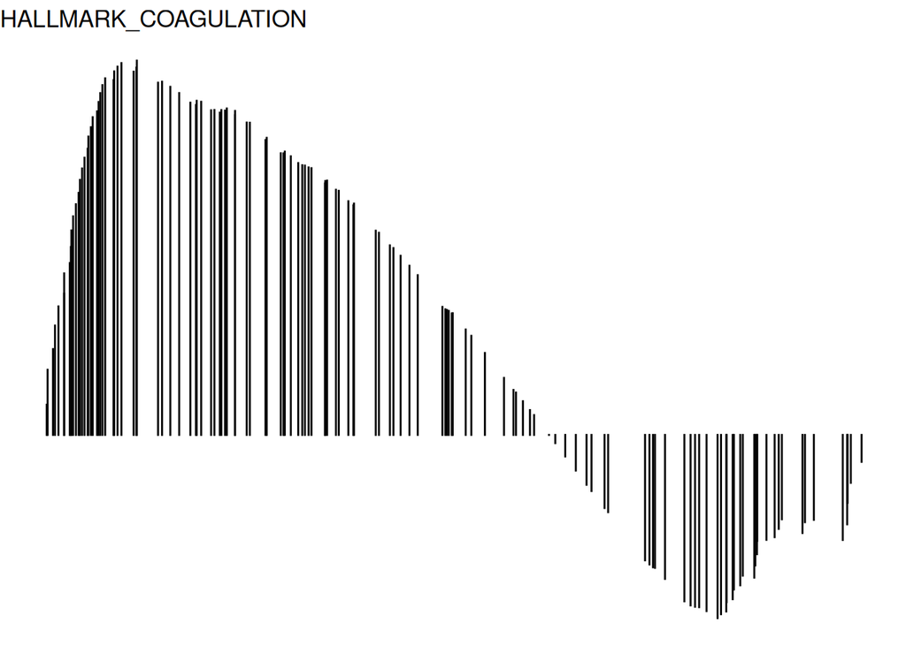

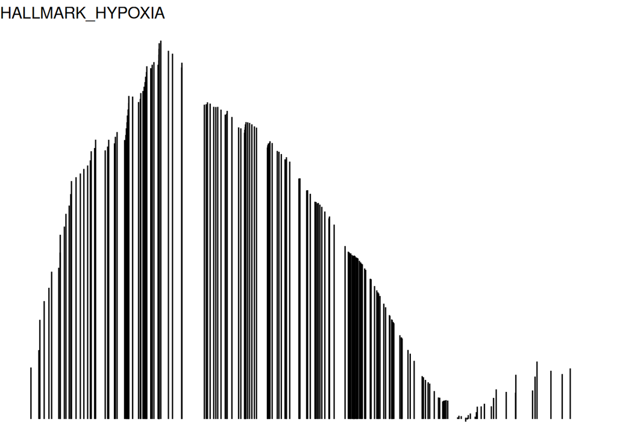

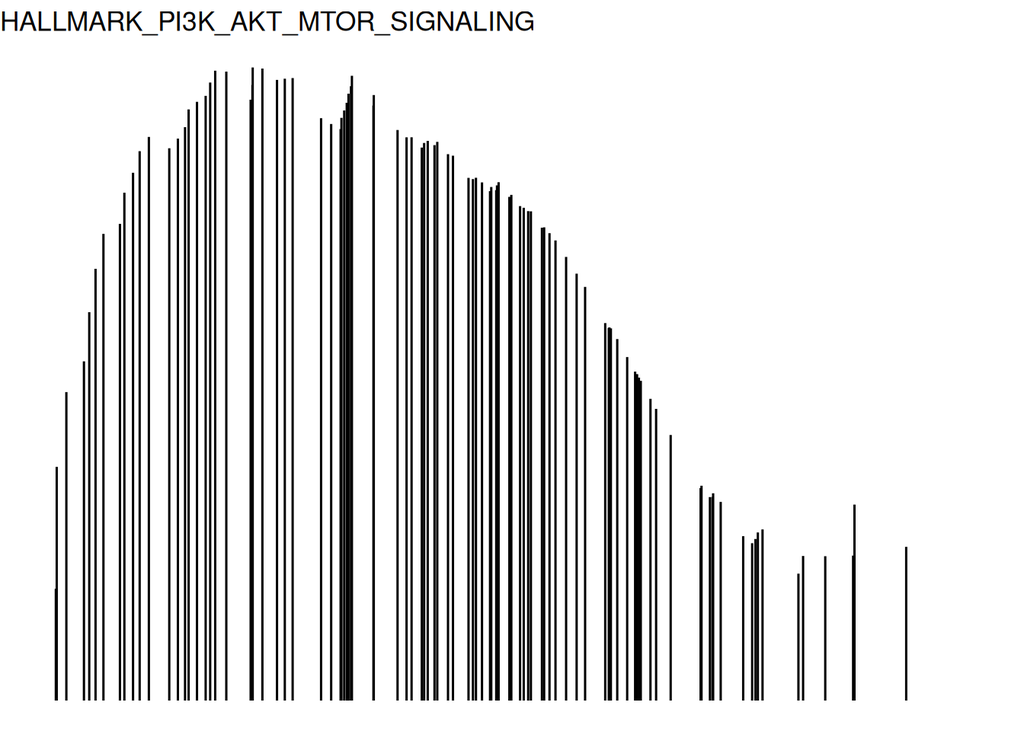

```r
pbar <- lapply(unique(result$pathway), function(ii) {
    dd <- result[result$pathway == ii,]
    ggplot(dd,aes(x=RANK.IN.GENE.LIST,y=RUNNING.ES))+
      geom_bar(stat="identity",colour = "black")+
      labs(x = ii, y = "", title = ii) +
      theme_void() + #不画坐标系 no coordinate system is drawn
      xlim(0, max(result$RANK.IN.GENE.LIST))
})
pbar
```

如果单画一条通路，那么这个热图应该画成有意义的。画多条就只能画这种假的了，仅用来表示左侧下调，右侧上调。

If a single pathway is drawn then this heatmap should be drawn to make sense. Drawing more than one would have to be this fake one, used only to indicate downward movement on the left and upward movement on the right.

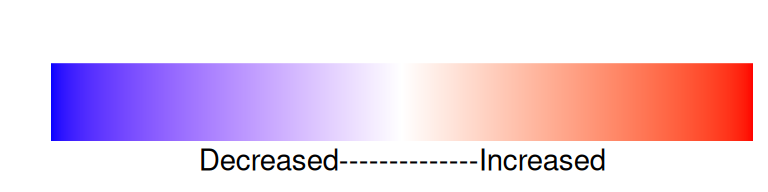

```r
t <- data.frame(a=as.numeric(1:1000),b=as.numeric(1:1000))

pheat <- ggplot(t,aes(a,1,fill=b)) +
  geom_tile()+
  theme_bw() + #去除背景色 remove background color
  labs(x = "Decreased--------------Increased", y = "", title = "") +
  scale_fill_gradient2(low = "blue", mid = "white", high = "red",midpoint = 500)+
  scale_x_discrete(expand = c(0, 0)) + scale_y_discrete(expand = c(0, 0)) +#让x和y轴都从0开始 let both the x and y axes start at 0
  theme(panel.grid =element_blank()) + #去除网格线 remove gridlines
  theme(panel.border = element_blank()) + #去除外层边框 remove outer border
  guides(fill=FALSE)#隐藏由fill产生的图例 hide the legend generated by fill
pheat
```

用cowplot组图

Combine images with cowplot

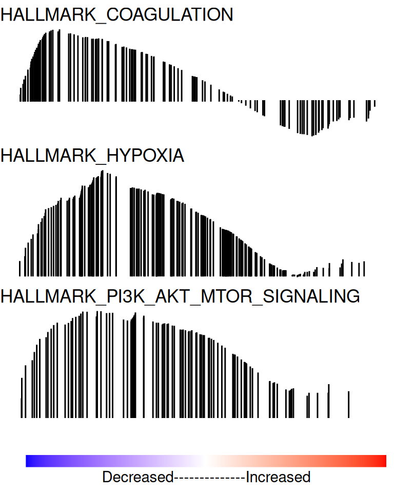

```r
pbar[[4]] <- pheat
plot_grid(plotlist=pbar, ncol=1,rel_heights = c(2,2,2,1))
```

```r
ggsave("prettyGSEAbar.pdf")
```